# Prediction using Supervised ML

Susmita Ghosh

15/12/2020

### 1.Predict the percentage of a student based on the no. of study hours.

### 2.What will be predicted score if a student studies for 9.25 hrs/ day?

**Here we use Simple Linear regression to predict the percentage of an student based on the no.of study hours.**

**Percentage of a student is our study or dependent variable and no of study hours is independent variable.**

**Let’s load the data first.**

```r
url<- "http://bit.ly/w-data"
data<- read.csv(url)
head(data)
```

```
##   Hours Scores
## 1   2.5     21
## 2   5.1     47
## 3   3.2     27
## 4   8.5     75
## 5   3.5     30
## 6   1.5     20
```

**Data description and summary:**

```r
str(data)
```

```
## 'data.frame':    25 obs. of  2 variables:
##  $ Hours : num  2.5 5.1 3.2 8.5 3.5 1.5 9.2 5.5 8.3 2.7 ...
##  $ Scores: int  21 47 27 75 30 20 88 60 81 25 ...
```

```r
summary(data)
```

```
##      Hours           Scores
##  Min.   :1.100   Min.   :17.00
##  1st Qu.:2.700   1st Qu.:30.00
##  Median :4.800   Median :47.00
##  Mean   :5.012   Mean   :51.48
##  3rd Qu.:7.400   3rd Qu.:75.00
##  Max.   :9.200   Max.   :95.00
```

**To visualize the data we do a Scatter plot between No of study hours and Percentage of a student.**

#### Scatter plot

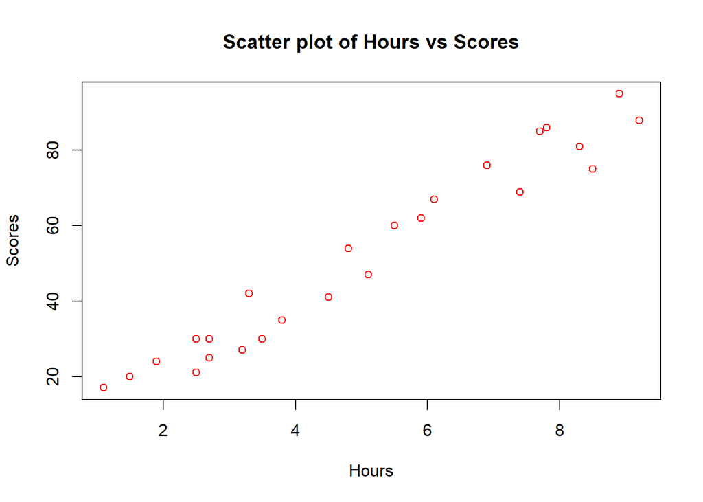

```r
plot(data,xlab="Hours",ylab="Scores",main= "Scatter plot of Hours vs Scores",col= "red")
```

**The scatter plot shows that there is a positive linear relationship between Percentage of a student and hours of study.**

**Let’s look at the correaltion coefficent between these two variable:**

```r
cor(data$Hours,data$Scores)
```

```
## [1] 0.9761907
```

**Now we are going to fit the linear model.**

#### The simple linear regression equation is given by: y=a+b*x;where,

*y= Dependent Variable*

*x= Independent Variable*

*a= Intercept*

*b= Slope*

#### Fit the linear model

```r
x=data$Hours
y=data$Scores
model<- lm(y~x,data)
summary(model)
```

```
##
## Call:
## lm(formula = y ~ x, data = data)
##
## Residuals:
##     Min      1Q  Median      3Q     Max
## -10.578  -5.340   1.839   4.593   7.265
##
## Coefficients:
##             Estimate Std. Error t value Pr(>|t|)
## (Intercept)   2.4837     2.5317   0.981    0.337
## x             9.7758     0.4529  21.583   <2e-16 ***
## ---
## Signif. codes:  0 '***' 0.001 '**' 0.01 '*' 0.05 '.' 0.1 ' ' 1
##
## Residual standard error: 5.603 on 23 degrees of freedom
## Multiple R-squared:  0.9529, Adjusted R-squared:  0.9509
## F-statistic: 465.8 on 1 and 23 DF,  p-value: < 2.2e-16
```

### Add Regression line to the Scatter Plot

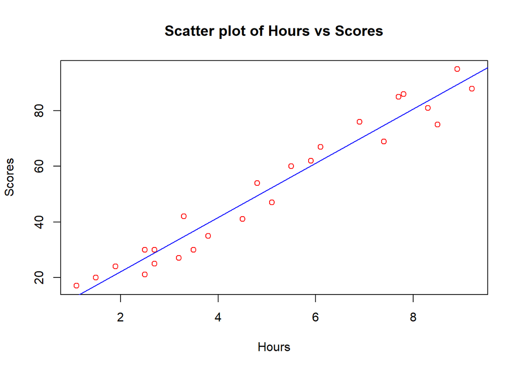

```r
x=data$Hours
y=data$Scores
model<- lm(y~x,data)
plot(data,xlab="Hours",ylab="Scores",main= "Scatter plot of Hours vs Scores",col= "red")
abline(model, col="blue")
```

### Predicted values based on the fitted model

```r
scores_predicted= model$fitted.values
scores_predicted
```

```
##        1        2        3        4        5        6        7        8
## 26.92318 52.34027 33.76624 85.57800 36.69899 17.14738 92.42106 56.25059
##        9       10       11       12       13       14       15       16
## 83.62284 28.87834 77.75736 60.16091 46.47479 34.74382 13.23706 89.48832
##       17       18       19       20       21       22       23       24
## 26.92318 21.05770 62.11607 74.82462 28.87834 49.40753 39.63173 69.93672
##       25
## 78.73494
```

### Data set containing original scores and predicted scores

```r
new_data= data.frame(data$Hours,data$Scores,scores_predicted)
head(new_data)
```

```
##   data.Hours data.Scores scores_predicted
## 1        2.5          21         26.92318
## 2        5.1          47         52.34027
## 3        3.2          27         33.76624
## 4        8.5          75         85.57800
## 5        3.5          30         36.69899
## 6        1.5          20         17.14738
```

### Plot predicted score vs original scores

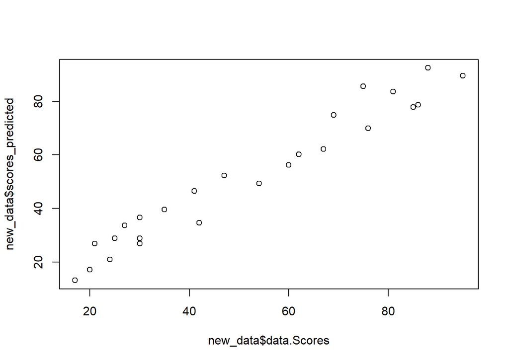

```r
plot(new_data$data.Scores,new_data$scores_predicted)
```

### Scores of a student who studied 9.25hrs/day

```r
new_x=data.frame(x=9.25)
predict(model, new_x)
```

```
##        1
## 92.90985
```

#### The Simple Linear Regression model for the given data set:y=2.4837+9.7758*x

**Summary of the model:** *1.The percentage of a student is 2.4837 when there is study hours is zero.*

*2.By the unit change in the study hours the percentage of a student increases by 9.7758 unit.*

*3. By the Adj R squared value we see that 95.09% of the variance found in the study variable(scores) can be explained by predictor variable(study hours).*